# Stat 579 - Homework #5

9/18/2018

## Flying etiquette

FiveThirtyEight is a website founded by Statistician and writer Nate Silver to publish results from opinion poll analysis, politics, economics, and sports blogging. One of the featured articles considers [flying etiquette](https://fivethirtyeight.com/features/airplane-etiquette-recline-seat/). This article is based on data collected by FiveThirtyEight and publicly available on github. Use the code below to read in the data from the survey:

```r
fly <- read.csv("https://raw.githubusercontent.com/fivethirtyeight/data/master/flying-etiquette-survey/flying-etiquette.csv")
library(classdata)
library(ggplot2)
library(dplyr)
library(tidyverse)
library(ggmosaic)
```

The following couple of lines of code provide a bit of cleanup of the demographic information by reaordering the levels of the corresponding factor variables. Run this code in your session.

```r
fly$Age <- factor(fly$Age, levels=c("18-29", "30-44", "45-60", "> 60", ""))
fly$Household.Income <- factor(fly$Household.Income, levels = c("$0 - $24,999","$25,000 - $49,999", "$50,000 - $99,999", "$100,000 - $149,999", "150000", ""))
fly$Education <- factor(fly$Education, levels = c("Less than high school degree", "High school degree", "Some college or Associate degree", "Bachelor degree",  "Graduate degree", ""))
```

1. Download the RMarkdown file with these homework instructions to use as a template for your work. Make sure to replace “Your Name” in the YAML with your name.
2. Some people do not travel often by plane. Provide a (visual) breakdown of travel frequency (use variable `How.often.do.you.travel.by.plane.`). Reorder the levels in the variable by travel frequency from least frequent travel to most frequent. Draw a barchart of travel frequency and comment on it.

```r
levels(fly$How.often.do.you.travel.by.plane.)
```

```
## [1] "A few times per month" "A few times per week"  "Every day"
## [4] "Never"                 "Once a month or less"  "Once a year or less"
```

```r
fly$How.often.do.you.travel.by.plane. <- factor(
  fly$How.often.do.you.travel.by.plane.,
  levels = c(   "Never","Once a year or less", "Once a month or less","A few times per month","A few times per week","Every day"))
levels(fly$How.often.do.you.travel.by.plane.)
```

```
## [1] "Never"                 "Once a year or less"   "Once a month or less"
## [4] "A few times per month" "A few times per week"  "Every day"
```

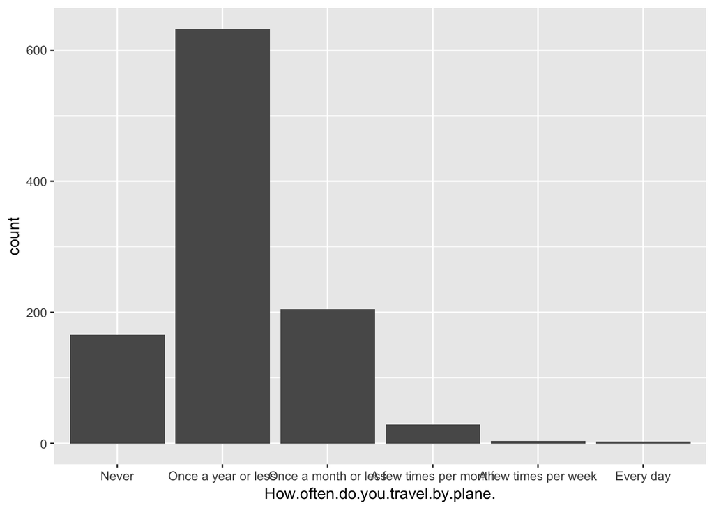

```r
ggplot(data=fly, aes(x= How.often.do.you.travel.by.plane.))+
  geom_bar()
```

There is a considerable amount of people who never travel by plane. If we ignore this group we can conclude that as the travel frequency change from least frequent travel to most frequent travel, number of people in the groups decrease.

More than half of the people travel at most once a year by plane. Group of people who travel at most once a month is the second group. Those people who fly very frequently (a few times per week or everyday) only forms a very small portition of the whole population.

Exclude all respondents who never fly from the remainder of the analysis. How many records does the data set have now?

```r
fly_new <- filter(fly, fly$How.often.do.you.travel.by.plane. != "Never")
nrow(fly_new)
```

```
## [1] 874
```

There are 874 records.

3. In the demographic variables (`Education`, `Age`, and `Houshold.Income`), replace all occurrences of the empty string "" by a missing value `NA`. How many responses in each variable do not have any missing values? How many responses have no missing values in any of the three variables? (Hint: think of the function `is.na`)

```r
fly_new$Education[fly_new$Education==""] <- NA
fly_new$Age[fly_new$Age==""] <- NA
fly_new$Household.Income[fly_new$Household.Income==""] <- NA


nrow(fly_new)-sum(is.na(fly_new$Education))
```

```
## [1] 837
```

```r
nrow(fly_new)-sum(is.na(fly_new$Age))
```

```
## [1] 843
```

```r
nrow(fly_new)-sum(is.na(fly_new$Household.Income))
```

```
## [1] 698
```

```r
nrow(fly_new)-sum(is.na(fly_new$Education)| is.na(fly_new$Age)|is.na(fly_new$Household.Income))
```

```
## [1] 696
```

837 records have no missing value in Education. 843 records have no missing value in Age. 698 records have no missing value in Household.Income 696 records have no missing value in any of the three variables.

4. Run the command below and interpret the output. What potential purpose can you see for the chart? What might be a problem with the chart? Find at least one purpose and one problem.

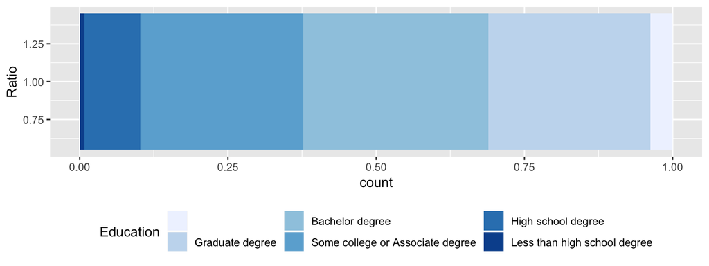

```r
library(ggplot2)
fly$Education = with(fly, factor(Education, levels = rev(levels(Education))))

ggplot(data = fly, aes(x = 1)) +
  geom_bar(aes(fill=Education), position="fill") +
  coord_flip() +
  theme(legend.position="bottom") +
  scale_fill_brewer() +
  xlab("Ratio")
```

5. Rename the variable `In.general..is.itrude.to.bring.a.baby.on.a.plane.` to `baby.on.plane.`. How many levels does the variable `baby.on.plane` have, and what are these levels? Rename the level labeled "" to “Not answered”. Bring the levels of `baby.on.plane` in an order from least rude to most rude. Put the level “Not answered” last. Draw a barchart of variable `baby.on.plane`. Interpret the result. (This question is very similar to question 2, but preps the data for the next question)

```r
fly_new$baby.on.plane <- fly_new$In.general..is.itrude.to.bring.a.baby.on.a.plane.
levels(fly_new$baby.on.plane)
```

```
## [1] ""                    "No, not at all rude" "Yes, somewhat rude"
## [4] "Yes, very rude"
```

```r
levels(fly_new$baby.on.plane) <- c("Not answered", "No, not at all rude", "Yes, somewhat rude", "Yes, very rude")
fly_new$baby.on.plane <- factor(
  fly_new$baby.on.plane,
  levels = c("No, not at all rude", "Yes, somewhat rude", "Yes, very rude","Not answered"))
levels(fly_new$baby.on.plane)
```

```
## [1] "No, not at all rude" "Yes, somewhat rude"  "Yes, very rude"
## [4] "Not answered"
```

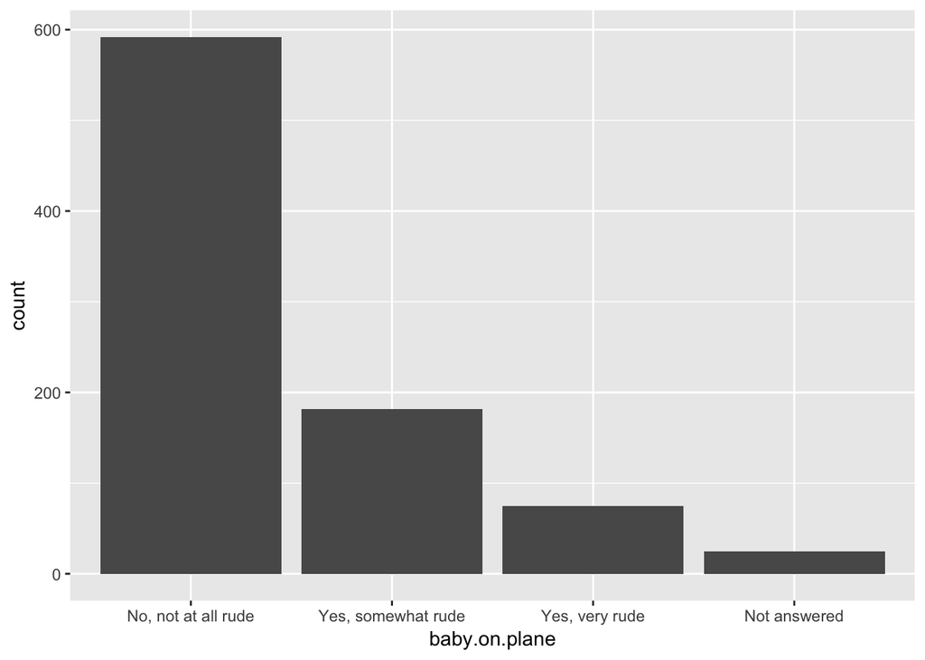

```r
ggplot(data=fly_new, aes(x = baby.on.plane))+
  geom_bar()
```

There are for levels: “No, not at all rude” “Yes, somewhat rude” “Yes, very rude” and "".

There is a group of people who did not answer this question. If we ignore this group we can conclude that as the level of rudeness increase in the answers number of people in the groups decrease. More than half of the people do not consider bringing a baby on plane rude. People who consider bring baby somewhat rude is the second group and who considers it very rude is the last group.

6. Investigate the relationship between gender and the variables `Do.you.have.any.children.under.18.` and `baby.on.plane`. How is the attitude towards babies on planes shaped by gender and own children under 18? Find a plot that summarises your findings (use `ggplot2`).

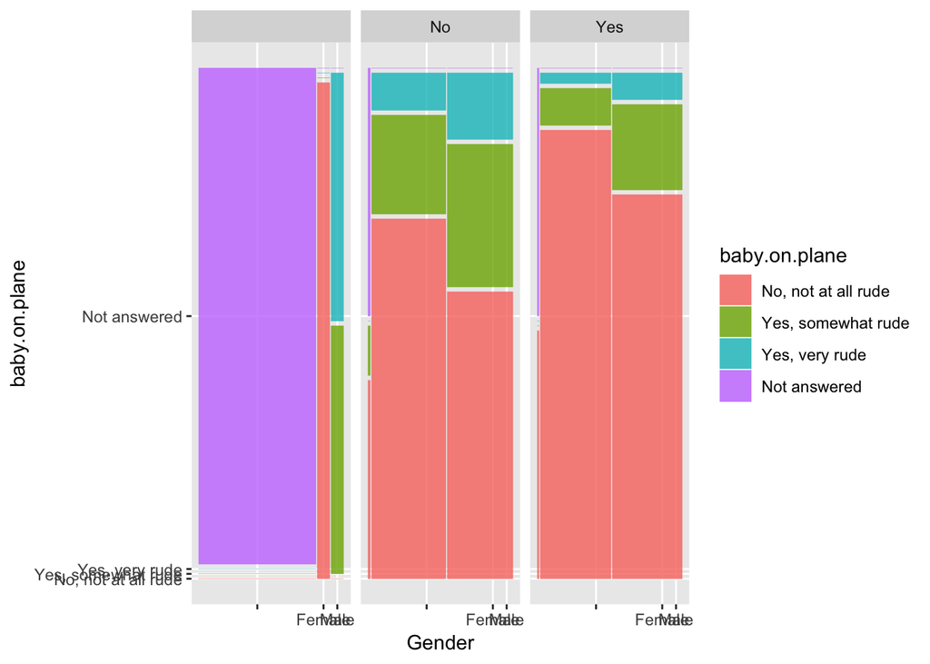

```r
ggplot(data = fly_new)+
      geom_mosaic( aes(x = product(Gender),
           fill= baby.on.plane,
           weight=1))+
     facet_grid(fly_new$Do.you.have.any.children.under.18.)
```

Women tolerate baby on plane much more than men. People who have children under 18 tolerate baby on plane much more than people who do not children under 18. People who do not answer the questions make the reading of plots difficult. When we eliminate those people the graph will be like below.

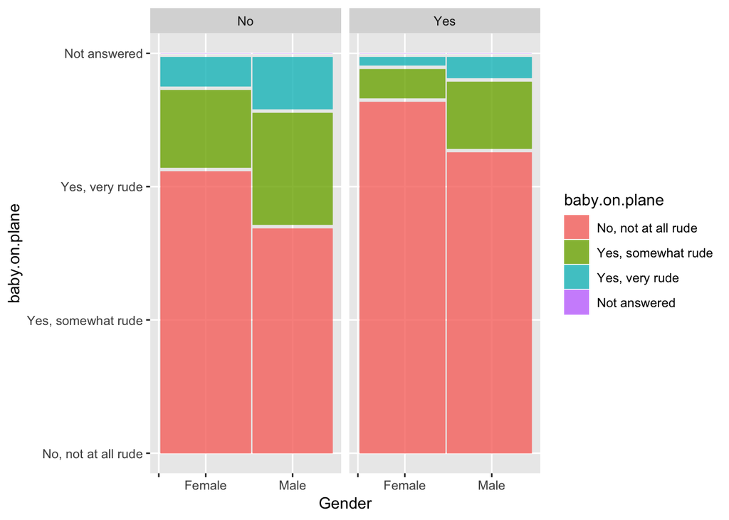

```r
fly_new$Do.you.have.any.children.under.18.[fly_new$Do.you.have.any.children.under.18.==""] <- NA
fly_new$Gender[fly_new$Gender==""] <- NA

final<-filter(fly_new, fly_new$Do.you.have.any.children.under.18.!= "NA"  & fly_new$Gender != "NA")


ggplot(data = final)+
      geom_mosaic( aes(x = product(Gender),
           fill= baby.on.plane,
           weight=1))+
     facet_grid(final$Do.you.have.any.children.under.18.)
```

Due date: the homework is due a week from now on Thursday.

For the submission: submit your solution in an R Markdown file and (just for insurance) submit the corresponding html/word file with it.